# Introduction to murine mouse model of obesity and microbiome data

Ewy Mathé

12 August, 2019

### Goals:

1. Explore the structure of the data
2. Assess the quality of the data
3. Identify microbes that are different between diet types and/or colonic location

### Requirements:

1. R or Rstudio
2. betareg package (install.packages(“betareg”))

### Input Data:

1. microbe.otus: a matrix containing proportion values of OTUs (groups of microbes).
2. sample.meta: annotation (meta-data) of the samples.
3. microbe.meta: annotation (meta-data) of the microbes.

### Tips:

- If you forget how a function is used in R, type “?function” to get more information
- Ask questions!!!

### 1. Explore the data types present in “Microbe_Data.RData”

Let us first load the data:

```r
load("/Users/math90/Documents/Teaching/Ethiopia/OHSI_DataAnalytics/Data/MurineColonDietStudy/Microbe_Data.RData")
```

Let’s see how big the objects are, and whether names of OTUs and samples are matching in the meta-data and in the proportion data.

```r
paste("microbe.meta has", nrow(microbe.meta), "rows and", ncol(microbe.meta),
    "columns")
```

```
## [1] "microbe.meta has 551 rows and 6 columns"
```

```r
paste("microbe.otus has", nrow(microbe.otus), "rows and", ncol(microbe.otus),
    "columns")
```

```
## [1] "microbe.otus has 551 rows and 274 columns"
```

```r
paste("sample.meta has", nrow(sample.meta), "rows and", ncol(sample.meta), "columns")
```

```
## [1] "sample.meta has 274 rows and 8 columns"
```

```r
head(microbe.meta)
```

```
##                          raw.ids          Phylum Class Order Family Genus
## 1             k__Bacteria.p__AD3             AD3  <NA>  <NA>   <NA>  <NA>
## 2   k__Bacteria.p__Acidobacteria   Acidobacteria  <NA>  <NA>   <NA>  <NA>
## 3  k__Bacteria.p__Actinobacteria  Actinobacteria  <NA>  <NA>   <NA>  <NA>
## 4 k__Bacteria.p__Armatimonadetes Armatimonadetes  <NA>  <NA>   <NA>  <NA>
## 5            k__Bacteria.p__BRC1            BRC1  <NA>  <NA>   <NA>  <NA>
## 6   k__Bacteria.p__Bacteroidetes   Bacteroidetes  <NA>  <NA>   <NA>  <NA>
```

```r
microbe.otus[1:5, 1:5]
```

```
##                                306PCMICROB 303MCMICROB 901PCMICROB
## k__Bacteria.p__AD3             0.000000000   0.0000000 0.000000000
## k__Bacteria.p__Acidobacteria   0.000000000   0.0000000 0.000000000
## k__Bacteria.p__Actinobacteria  0.003047558   0.0471917 0.000189122
## k__Bacteria.p__Armatimonadetes 0.000000000   0.0000000 0.000000000
## k__Bacteria.p__BRC1            0.000000000   0.0000000 0.000000000
##                                 901MCMICROB  902PCMICROB
## k__Bacteria.p__AD3             0.0000000000 0.0000000000
## k__Bacteria.p__Acidobacteria   0.0000000000 0.0000000000
## k__Bacteria.p__Actinobacteria  0.0005836283 0.0005520447
## k__Bacteria.p__Armatimonadetes 0.0000000000 0.0000000000
## k__Bacteria.p__BRC1            0.0000000000 0.0000000000
```

```r
head(sample.meta)
```

```
##            ID Batch Cohort Combined_Diet Initiation_Diet Progression_Diet
## 1 306PCMICROB     1      1            CE               C                E
## 2 303MCMICROB     1      1            CE               C                E
## 3 901PCMICROB     1      1            EE               E                E
## 4 901MCMICROB     1      1            EE               E                E
## 5 902PCMICROB     1      1            EE               E                E
## 6 905PCMICROB     1      1            EE               E                E
##   Colonic_Site OTU_Count
## 1           PC      1020
## 2           MC       613
## 3           PC      1271
## 4           MC       880
## 5           PC      1098
## 6           PC      1093
```

```r
# check that meta-data and proportaion data are matching
all.equal(as.character(microbe.meta$raw.ids), rownames(microbe.otus))
```

```
## [1] TRUE
```

```r
all.equal(as.character(sample.meta$ID), colnames(microbe.otus))
```

```
## [1] TRUE
```

Let’s now explore the meta data for the samples a bit, and see how many mice we have per group:

```r
summary(sample.meta)
```

```
##       ID                Batch          Cohort          Combined_Diet
##  Length:274         Min.   :1.000   Length:274         CE     :70
##  Class :character   1st Qu.:2.000   Class :character   EE     :69
##  Mode  :character   Median :2.000   Mode  :character   HE     :38
##                     Mean   :2.179                      CH     :24
##                     3rd Qu.:3.000                      CC     :22
##                     Max.   :3.000                      EC     :17
##                                                        (Other):34
##  Initiation_Diet    Progression_Diet   Colonic_Site   OTU_Count
##  Length:274         Length:274         DC:86        Min.   : 207
##  Class :character   Class :character   MC:92        1st Qu.: 711
##  Mode  :character   Mode  :character   PC:96        Median :1024
##                                                     Mean   :1016
##                                                     3rd Qu.:1286
##                                                     Max.   :2050
##
```

Now let us look at how many OTUs we have at each taxonomic level (e.g. Phylum, Class, Order, Family, Genus):

```r
head(microbe.meta)
```

```
##                          raw.ids          Phylum Class Order Family Genus
## 1             k__Bacteria.p__AD3             AD3  <NA>  <NA>   <NA>  <NA>
## 2   k__Bacteria.p__Acidobacteria   Acidobacteria  <NA>  <NA>   <NA>  <NA>
## 3  k__Bacteria.p__Actinobacteria  Actinobacteria  <NA>  <NA>   <NA>  <NA>
## 4 k__Bacteria.p__Armatimonadetes Armatimonadetes  <NA>  <NA>   <NA>  <NA>
## 5            k__Bacteria.p__BRC1            BRC1  <NA>  <NA>   <NA>  <NA>
## 6   k__Bacteria.p__Bacteroidetes   Bacteroidetes  <NA>  <NA>   <NA>  <NA>
```

```r
unique(microbe.meta$Phylum)
```

```
##  [1] AD3               Acidobacteria     Actinobacteria
##  [4] Armatimonadetes   BRC1              Bacteroidetes
##  [7] Chloroflexi       Cyanobacteria     Deferribacteres
## [10] Elusimicrobia     FBP               Firmicutes
## [13] Fusobacteria      GAL15             Nitrospirae
## [16] Planctomycetes    Proteobacteria    SR1
## [19] Spirochaetes      Synergistetes     TM6
## [22] TM7               Tenericutes       Verrucomicrobia
## [25] WPS.2             .Thermi.          AD3.c
## [28] Acidobacteria.c   Actinobacteria.c  Armatimonadetes.c
## [31] BRC1.c            Bacteroidetes.c   Chloroflexi.c
## [34] Cyanobacteria.c   Deferribacteres.c Elusimicrobia.c
## [37] FBP.c             Firmicutes.c      Fusobacteria.c
## [40] GAL15.c           Nitrospirae.c     Planctomycetes.c
## [43] Proteobacteria.c  SR1.c             Spirochaetes.c
## [46] Synergistetes.c   TM6.c             TM7.c
## [49] Tenericutes.c     Verrucomicrobia.c WPS.2.c
## [52] .Thermi..c
## 52 Levels: .Thermi. .Thermi..c Acidobacteria ... WPS.2.c
```

```r
paste("There are", length(unique(microbe.meta$Phylum)), "Phyla")
```

```
## [1] "There are 52 Phyla"
```

```r
paste("There are", length(unique(microbe.meta$Class)), "Classes")
```

```
## [1] "There are 115 Classes"
```

```r
paste("There are", length(unique(microbe.meta$Order)), "Orders")
```

```
## [1] "There are 94 Orders"
```

```r
paste("There are", length(unique(microbe.meta$Family)), "Families")
```

```
## [1] "There are 156 Families"
```

```r
paste("There are", length(unique(microbe.meta$Genus)), "Genuses")
```

```
## [1] "There are 316 Genuses"
```

Now we can start looking at the proportions, starting with a boxplot:

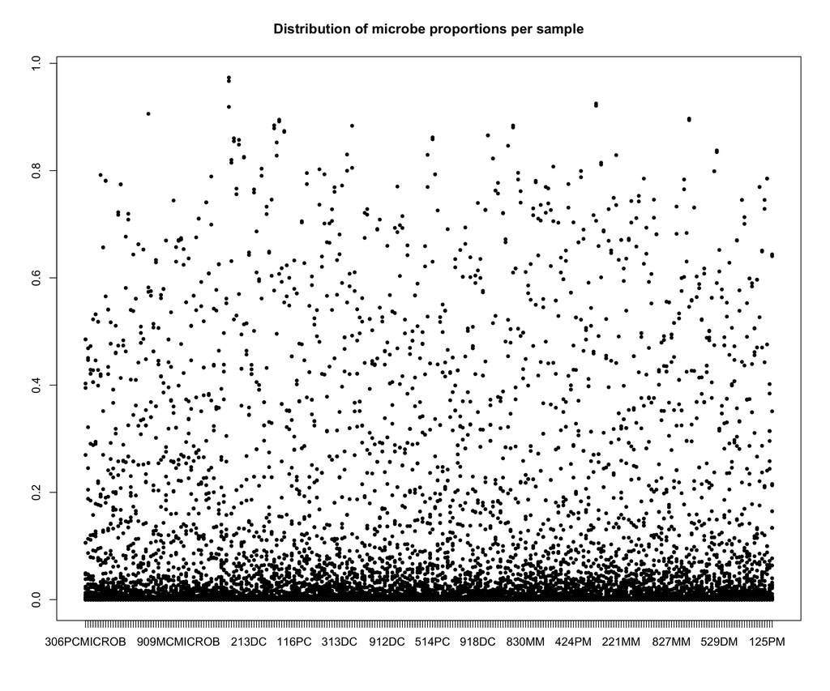

```r
boxplot(microbe.otus, pch = 19, cex = 0.6, main = "Distribution of microbe proportions per sample")
```

That does not look very informative. Any ideas why?

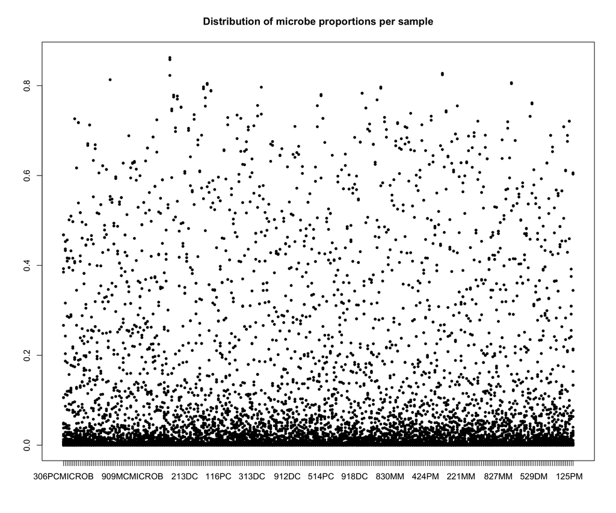

```r
boxplot(asinh(microbe.otus), pch = 19, cex = 0.6, main = "Distribution of microbe proportions per sample")
```

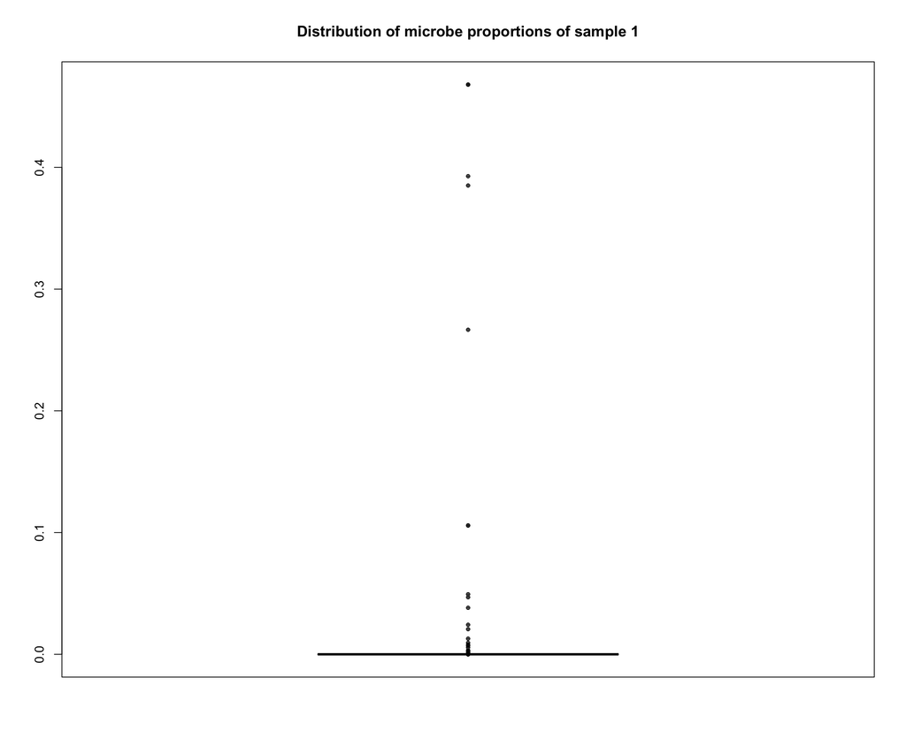

```r
boxplot(asinh(microbe.otus[, 1]), pch = 10, cex = 0.6, main = "Distribution of microbe proportions of sample 1")
```

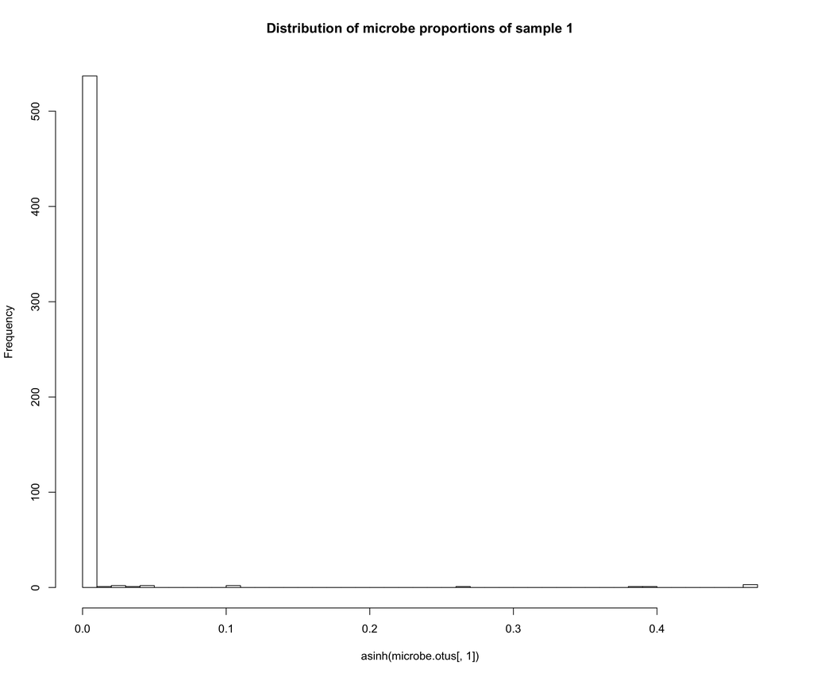

```r
hist(asinh(microbe.otus[, 1]), breaks = 50, main = "Distribution of microbe proportions of sample 1")
```

### 2. phyla by dietary group (e.g. initiation diet)

First, get the indices of the samples for each initation diet group:

```r
C <- which(sample.meta$Initiation_Diet == "C")
E <- which(sample.meta$Initiation_Diet == "E")
H <- which(sample.meta$Initiation_Diet == "H")
length(C)
```

```
## [1] 116
```

```r
length(E)
```

```
## [1] 99
```

```r
length(H)
```

```
## [1] 59
```

```r
table(sample.meta$Initiation_Diet)
```

```
##
##   C   E   H
## 116  99  59
```

Now we can calculate the mean per diet group for each OTU:

```r
aveC <- aveE <- aveH <- c()
for (i in 1:nrow(microbe.otus)) {
    aveC <- c(aveC, mean(microbe.otus[i, C]))
    aveE <- c(aveE, mean(microbe.otus[i, E]))
    aveH <- c(aveH, mean(microbe.otus[i, H]))
}
names(aveC) <- names(aveE) <- names(aveH) <- rownames(microbe.otus)
```

We can look to see how these averages are distributed across the 3 groups.

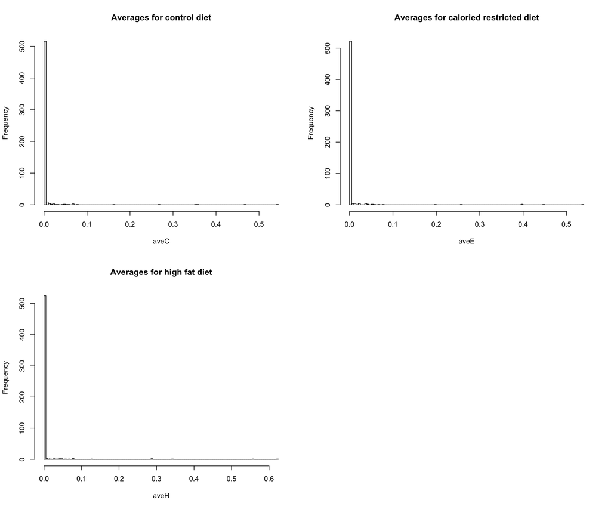

```r
par(mfrow = c(2, 2))
hist(aveC, main = "Averages for control diet", breaks = 100)
hist(aveE, main = "Averages for caloried restricted diet", breaks = 100)
hist(aveH, main = "Averages for high fat diet", breaks = 100)
```

Discussion: Is this what you expect? What are the dominating OTUs in each group?

```r
# top for control
rownames(microbe.otus)[order(aveC, decreasing = T)[1:5]]
```

```
## [1] "k__Bacteria.p__Firmicutes"
## [2] "k__Bacteria.p__Firmicutes.c__Clostridia"
## [3] "k__Bacteria.p__Bacteroidetes"
## [4] "k__Bacteria.p__Bacteroidetes.c__Bacteroidia"
## [5] "k__Bacteria.p__Firmicutes.c__Clostridia.o__Clostridiales.f__.g__"
```

```r
# top for high fat
rownames(microbe.otus)[order(aveH, decreasing = T)[1:5]]
```

```
## [1] "k__Bacteria.p__Firmicutes"
## [2] "k__Bacteria.p__Firmicutes.c__Clostridia"
## [3] "k__Bacteria.p__Firmicutes.c__Clostridia.o__Clostridiales.f__.g__"
## [4] "k__Bacteria.p__Bacteroidetes"
## [5] "k__Bacteria.p__Bacteroidetes.c__Bacteroidia"
```

```r
# top for calorie restricted
rownames(microbe.otus)[order(aveE, decreasing = T)[1:5]]
```

```
## [1] "k__Bacteria.p__Firmicutes"
## [2] "k__Bacteria.p__Firmicutes.c__Clostridia"
## [3] "k__Bacteria.p__Bacteroidetes"
## [4] "k__Bacteria.p__Bacteroidetes.c__Bacteroidia"
## [5] "k__Bacteria.p__Firmicutes.c__Clostridia.o__Clostridiales.f__.g__"
```

Is this what you expect?

```r
top5C <- rownames(microbe.otus)[order(aveC, decreasing = T)[1:5]]
top5E <- rownames(microbe.otus)[order(aveE, decreasing = T)[1:5]]
top5H <- rownames(microbe.otus)[order(aveH, decreasing = T)[1:5]]

alltop5 <- unique(c(top5C, top5E, top5H))
length(alltop5)
```

```
## [1] 5
```

```r
alltop5
```

```
## [1] "k__Bacteria.p__Firmicutes"
## [2] "k__Bacteria.p__Firmicutes.c__Clostridia"
## [3] "k__Bacteria.p__Bacteroidetes"
## [4] "k__Bacteria.p__Bacteroidetes.c__Bacteroidia"
## [5] "k__Bacteria.p__Firmicutes.c__Clostridia.o__Clostridiales.f__.g__"
```

The variable “alltop5” represents the unique microbes that have the highest averages within each diet group. We can now make a data frame of the abundances for these top 5 and plot them as a stacked barplot.

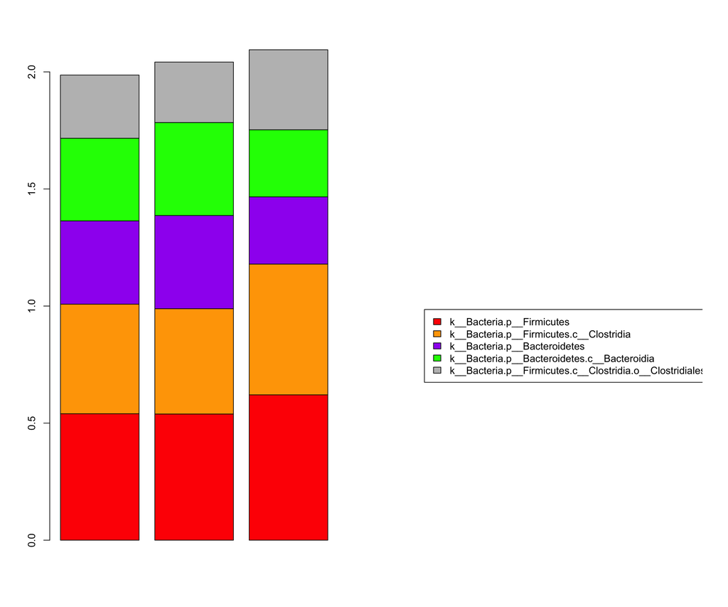

```r
mymatrix <- cbind(aveC[alltop5], aveE[alltop5], aveH[alltop5])
rownames(mymatrix) <- alltop5

par(mfrow = c(1, 2))
barplot(mymatrix, col = c("red", "orange", "purple", "green", "grey"))
plot(1:20, 1:20, type = "n", xaxt = "n", yaxt = "n", xlab = "", ylab = "", bty = "n")
legend(1, 10, alltop5, fill = c("red", "orange", "purple", "green", "grey"))
```

Is this what you expect?

### 3. Identify OTU differences by diet group

According to the paper, ANOVA was applied to look for OTU differences by diet type. Specifically, parameters for ANOVA included taking into account the fact that sample sizes are unbalanced, and the models were adjusted for phase 1 diet, phase 2 diet, cohort, and colonic segment.

However, without the count data, this is difficult to do.

Rather, let us run a beta regression model:

```r
library(betareg)
# Filter OTUs where genera has at > 1% abundance
maxOTUs <- as.numeric(apply(microbe.otus, 1, max))
keepers <- which(maxOTUs > 0.1)
length(keepers)
```

```
## [1] 38
```

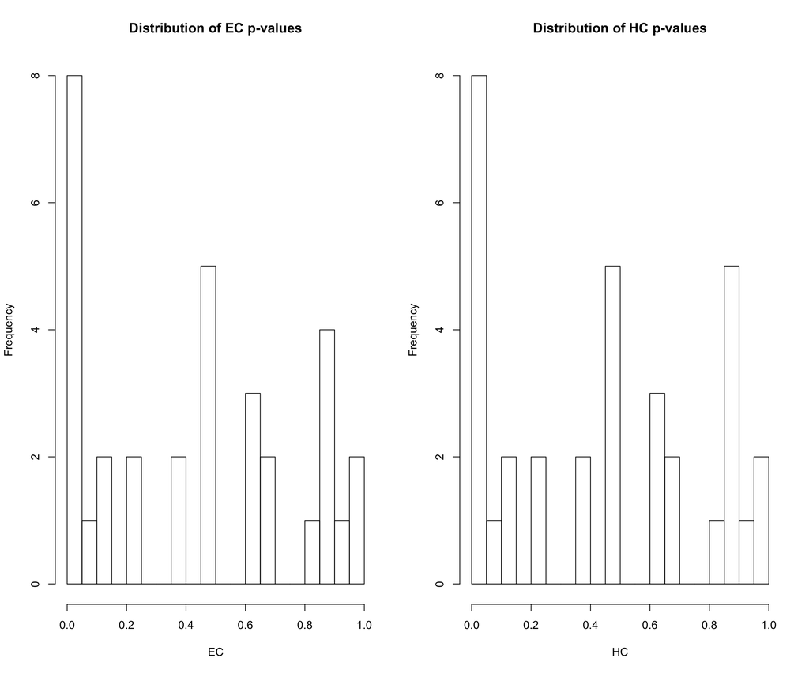

```r
newmicrobe.otus <- asinh(sqrt(microbe.otus[keepers, ]))

# Also check that enough samples (min # in one diet group) have non-zero
# values
mycut <- min(table(sample.meta$Initiation_Diet))
props <- as.numeric(apply(newmicrobe.otus, 1, function(x) length(which(x ==
    0))))
newmicrobe.otus <- newmicrobe.otus[which(props < mycut), ]

# Now run regression models:
EC <- HC <- c()
for (i in 1:nrow(newmicrobe.otus)) {
    temp <- newmicrobe.otus[i, ] + 1e-10
    out <- betareg(temp ~ sample.meta$Initiation_Diet + sample.meta$Batch +
        sample.meta$Progression_Diet, link = "logit")
    EC <- c(EC, summary(out)$coefficients$mean["sample.meta$Initiation_DietE",
        "Pr(>|z|)"])
    HC <- c(EC, summary(out)$coefficients$mean["sample.meta$Initiation_DietH",
        "Pr(>|z|)"])
}

# Let's plot the p-values:
par(mfrow = c(1, 2))
hist(EC, breaks = 30, main = "Distribution of EC p-values")
hist(HC, breaks = 30, main = "Distribution of HC p-values")
```

Now we can adjust for multiple comparisons and see what types of microbes we get as significant:

```r
allp <- c(EC, HC)
allp.adj = p.adjust(allp)

which(allp.adj < 0.1)
```

```
## [1] 21 54
```

```r
which(allp < 0.05)
```

```
##  [1]  1  2  7  8 17 21 22 24 34 35 40 41 50 54 55 57
```

```r
# Significant microbes different between calorie-restricted and control
# diets
rownames(newmicrobe.otus)[intersect(which(allp.adj < 0.1), 1:length(EC))]
```

```
## [1] "k__Bacteria.p__Bacteroidetes.c__Bacteroidia.o__Bacteroidales.f__S24.7.g__"
```

```r
# Significant microbes different between calorie-restricted and control
# diets
rownames(newmicrobe.otus)[(intersect(which(allp.adj < 0.1), length(HC):(length(HC) *
    2))) - length(HC)]
```

```
## [1] "k__Bacteria.p__Bacteroidetes.c__Bacteroidia.o__Bacteroidales.f__Rikenellaceae.g__"
```

```r
# Now using a p<0.05 cutoff: Significant microbes different between
# calorie-restricted and control diets
rownames(newmicrobe.otus)[intersect(which(allp < 0.05), 1:length(EC))]
```

```
## [1] "k__Bacteria.p__Actinobacteria"
## [2] "k__Bacteria.p__Bacteroidetes"
## [3] "k__Bacteria.p__Actinobacteria.c__Actinobacteria"
## [4] "k__Bacteria.p__Bacteroidetes.c__Bacteroidia"
## [5] "k__Bacteria.p__Bacteroidetes.c__Bacteroidia.o__Bacteroidales.f__Bacteroidaceae.g__Bacteroides"
## [6] "k__Bacteria.p__Bacteroidetes.c__Bacteroidia.o__Bacteroidales.f__S24.7.g__"
## [7] "k__Bacteria.p__Bacteroidetes.c__Bacteroidia.o__Bacteroidales.f__.Odoribacteraceae..g__Butyricimonas"
## [8] "k__Bacteria.p__Firmicutes.c__Bacilli.o__Lactobacillales.f__Lactobacillaceae.g__Lactobacillus"
```

```r
# Significant microbes different between calorie-restricted and control
# diets
rownames(newmicrobe.otus)[(intersect(which(allp < 0.05), length(HC):(length(HC) *
    2))) - length(HC)]
```

```
## [1] "k__Bacteria.p__Actinobacteria"
## [2] "k__Bacteria.p__Verrucomicrobia"
## [3] "k__Bacteria.p__Actinobacteria.c__Actinobacteria"
## [4] "k__Bacteria.p__Verrucomicrobia.c__Verrucomicrobiae"
## [5] "k__Bacteria.p__Bacteroidetes.c__Bacteroidia.o__Bacteroidales.f__Rikenellaceae.g__"
## [6] "k__Bacteria.p__Bacteroidetes.c__Bacteroidia.o__Bacteroidales.f__S24.7.g__"
## [7] "k__Bacteria.p__Deferribacteres.c__Deferribacteres.o__Deferribacterales.f__Deferribacteraceae.g__Mucispirillum"
```